# Relating Confidence Intervals and Hypothesis Tests

Chester Ismay

5/2/2017

## Too Much Coffee?

In one experiment, 14 researchers trained a random sample of male US liberal arts college students to tap their fingers at a rapid rate. The sample was then divided at random into two groups of 10 students each. Each student drank the equivalent of about two cups of coffee, which included about 200 mg of caffeine for the students in one group but was decaffeinated coffee for the second group. After a 2-hour period, each student was tested to measure finger tapping rate (taps per minute). The students did not know whether or not their drinks included caffeine and the person measuring the tap rates was also unaware of the groups. The goal of the experiment was to determine whether caffeine produces an increase in the average tap rate.

1. What is the response variable for this problem?
2. What is the explanatory variable?
3. What is the population in this problem?
4. Why was random sampling used to select the observational units?
5. Denote $\mu_c$ as the mean tap rate for the population of male students with caffeine and $\mu_n$ as the similar rate without caffeine. Identify the correct alternative hypothesis.
6. For this problem, we have an observed difference in sample means of $\bar{x}_c - \bar{x}_n$ of 3.5. Based on the picture, is there evidence that caffeine increases tap rate?

[output not shown]

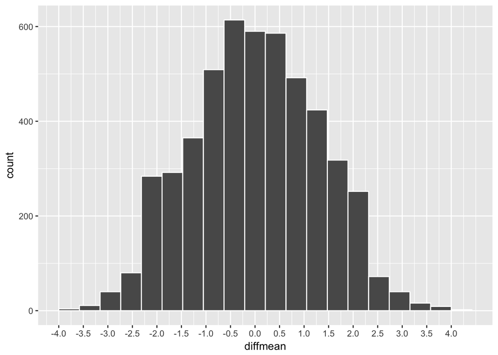

7. Suppose that the goal of the experiment was to determine whether caffeine produces an EFFECT in the average tap rate. What could we say about the corresponding confidence interval based on the size of the $p$-value on the last slide?